# CPSC 441 Group Project Group3

Andrea Dest, Steven Krauklis, and Shujie Wu

10/16/2020

## Introduction

**The data set we are working with is the lyrics in albums of Taylor Swift. It is retrieved from the 2020/09/29 file of the tidytuesdayR database. We are particularly interested in the total words of each album, the number of different types of pronouns of each album, and how words per minute differ in each album and by writers.**

## Initial Setup: load in Lyrics Data

```r
library(tidyverse)
library(data.table)
```

```r
library(ggplot2)
library(dplyr)
library(viridis)
library(ggridges)
library(lubridate)
library(ggpmisc)
lyrics_swift <- fread("https://raw.githubusercontent.com/rfordatascience/tidytuesday/master/data/2020/2020-09-29/taylor_swift_lyrics.csv", header =T)
```

## First variable: Total words in each album

**We would like to see how lines-intensive are Taylor’s songs and how that differs among albums.**

**1. Create the new variable total words and make a ridgeline plot to show number of words in each album**

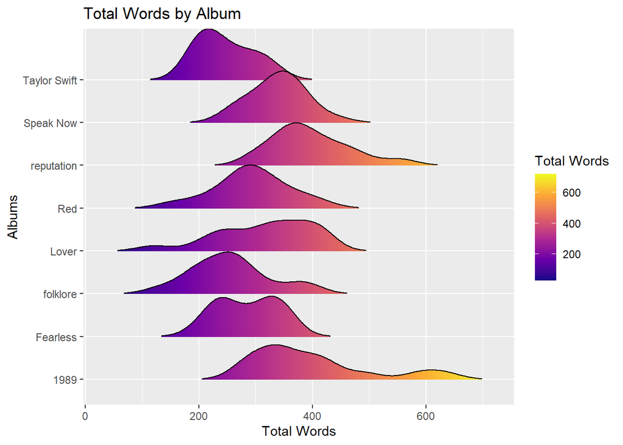

```r
#Count the total words in each song and make a new variable in the table
lyrics_swift <- mutate(lyrics_swift, total_words = sapply(strsplit(lyrics_swift$Lyrics, " "), length))
#Plot the total words of songs in each album
total_word_plot <- ggplot(lyrics_swift, aes(x=total_words, y=Album, fill = stat(x))) + geom_density_ridges_gradient(scale = 1.2, rel_min_height = 0.01) +
  scale_fill_viridis_c(name = "Total Words", option = "C") + ylab("Albums") + xlab("Total Words") + ggtitle("Total Words by Album")
total_word_plot
```

```r
#Save the plot
ggsave(filename = "Total Words by Album", plot = total_word_plot, device = "png")
```

**The plot shows the distribution of words in each album.**

**2. Statistical data for total words**

```r
#Get stats about mean, variance, sd, median, and range for total words in each album
stat_words<-lyrics_swift%>%
  group_by(Album)%>%
  summarise(mean_words = mean(total_words),
            variance_words = var(total_words),
            sd_words = sd(total_words),
            median_words = median(total_words),
            range_words = max(total_words)-min(total_words))%>%
  arrange(mean_words)
print(stat_words)
```

```
## # A tibble: 8 x 6
##   Album        mean_words variance_words sd_words median_words range_words
##   <chr>             <dbl>          <dbl>    <dbl>        <dbl>       <int>
## 1 Taylor Swift       246.          2164.     46.5         234.         135
## 2 folklore           255.          4824.     69.5         254.         261
## 3 Fearless           285.          2644.     51.4         290          158
## 4 Red                292           4301.     65.6         286          268
## 5 Lover              315.          6982.     83.6         329          302
## 6 Speak Now          338.          2223.     47.2         338          185
## 7 1989               395.         11083.    105.          363          357
## 8 reputation         397.          4653.     68.2         377          256
```

**From the table we can see that by average “reputation” has the most words, “Taylor Swift” has the least words, and “1989” is the most diverse in words numbers.**

**3. Save mean for total words as a text file**

```r
#Subset variables album and mean and save as a text file
stat_words%>%
  select(Album, mean_words)%>%
  write.table(file = "Mean_totalwords_albums", quote = F, sep = "   ")
```

## Second variable: Different types of pronouns in each album

**Other than the total words, we would like to see how Taylor uses different pronouns in her albums, and which pronoun is her favorite.**

**1. Data manipulation for counting pronouns and form a new table. Make a graph for visualization**

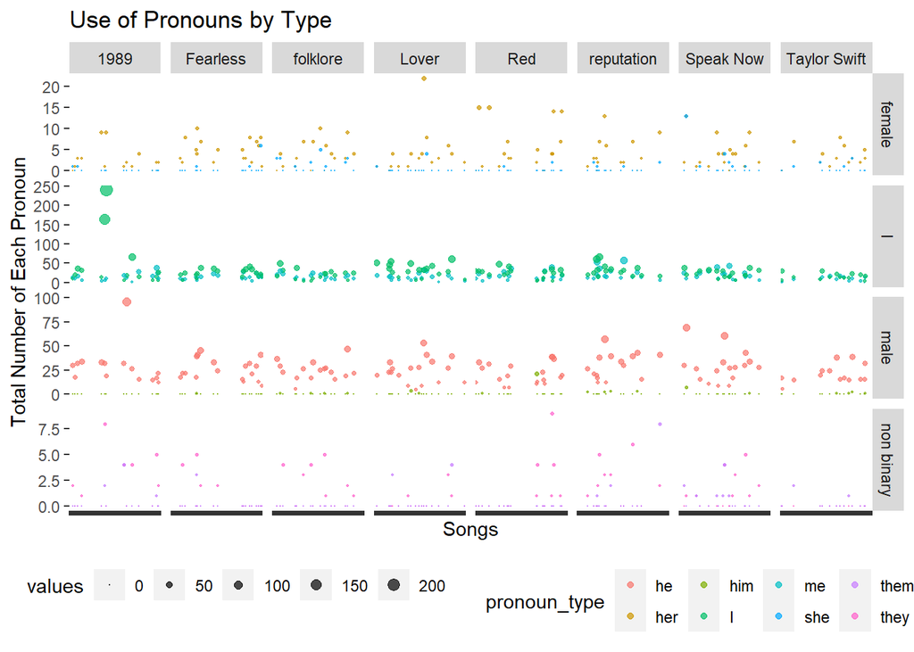

```r
#Count each type of pronouns
pronouns <- lyrics_swift %>%
  mutate(her=(str_count(Lyrics, "her"))) %>%
  mutate(he=(str_count(Lyrics, "he"))) %>%
  mutate(they=(str_count(Lyrics, "they"))) %>%
  mutate(them=(str_count(Lyrics, "them"))) %>%
  mutate(she=(str_count(Lyrics, "she"))) %>%
  mutate(him=(str_count(Lyrics, "him"))) %>%
  mutate(me=(str_count(Lyrics, "me"))) %>%
  mutate(I=(str_count(Lyrics, "I"))) %>%
  pivot_longer(her:I, names_to = "pronoun_type", values_to="values") %>%
  mutate(type = case_when(xor(pronoun_type == "her", pronoun_type == "she") ~ "female",
                         xor(pronoun_type == "he", pronoun_type == "him") ~ "male",
                         xor(pronoun_type == "they", pronoun_type == "them") ~ "non binary",
                         xor(pronoun_type == "I", pronoun_type == "me") ~ "I"
))

#Make the graph
pronoun_plot <- ggplot(pronouns, aes(x=Title, y=values, size = values)) + geom_point(alpha =0.7, aes(color = pronoun_type)) + scale_size(range = c(.1, 3)) + ggtitle("Use of Pronouns by Type") + ylab("Total Number of Each Pronoun") + xlab("Songs") + theme(legend.position="bottom") + theme(axis.text.x=element_blank())
pronoun_plot1<-pronoun_plot + facet_grid(type~Album, scales ="free_y")
pronoun_plot1
```

```r
#Save the graph
ggsave(filename = "Use of Pronouns by Type", plot = pronoun_plot1, device = "png")
```

**The graph shows the use of different pronouns in different albums. Pronouns are grouped by four different types:“I”, “Female”, “Male”, “Non-binary”.**

**2. Statistical data for pronouns**

```r
#Get stats about mean, variance, sd, median, and range for different types of pronouns in each album
stat_pronouns<-pronouns%>%
  group_by(Album,type)%>%
  summarise(mean_pronouns = mean(values),
            var_pronouns = var(values),
            sd_pronouns = sd(values),
            median_pronouns = median(values),
            range_pronouns = max(values)-min(values))%>%
  arrange(mean_pronouns)
print(stat_pronouns)
```

```
## # A tibble: 32 x 7
## # Groups:   Album [8]
##    Album type  mean_pronouns var_pronouns sd_pronouns median_pronouns
##    <chr> <chr>         <dbl>        <dbl>       <dbl>           <dbl>
##  1 Tayl~ non ~         0.107        0.173       0.416               0
##  2 Lover non ~         0.333        0.914       0.956               0
##  3 Fear~ non ~         0.444        1.45        1.21                0
##  4 Red   non ~         0.526        2.85        1.69                0
##  5 folk~ non ~         0.625        1.92        1.39                0
##  6 Spea~ non ~         0.824        1.79        1.34                0
##  7 1989  non ~         1.1          3.96        1.99                0
##  8 repu~ non ~         1.1          4.16        2.04                0
##  9 1989  fema~         1.33         5.54        2.35                0
## 10 Tayl~ fema~         1.89         5.36        2.31                1
## # ... with 22 more rows, and 1 more variable: range_pronouns <int>
```

**The data shows that “I” is being used the most. The second place is taken by “male” pronouns. “female” comes in third and “non-binary” is in the last.**

**3. Save mean of each pronouns as a text file**

```r
#Subset variables album and mean and save as a text file
stat_pronouns%>%
  select(Album, type, mean_pronouns)%>%
  write.table(file = "Mean_pronouns_albums", sep = "   ", quote = F)
```

## Third Variable: Words per minute of each album.

**At last, knowing the total words cannot best indicate the how word-intense are Taylor’s songs due to different lengths of each song. Therefore we introduce this variable to look at the words per minute and how words/minute of songs written by Taylor along differ from that written by Taylor with other writers.**

**1. Read data. Song lengths and writers taken from album notes via wikipedia**

```r
tdisc<-read.csv("https://raw.githubusercontent.com/andreakdest/GROUP3/main/Tswift%20-%20Sheet1.csv")
```

**2. Get song names fixed**

```r
#fix apostrophe error so that we can combine two tables later successfully
lyrics_swift$Title<-gsub("â€™","'",lyrics_swift$Title)

#add quotations/remove case to song titles
tdisc$Title<-tolower(tdisc$Title)
ls<-lyrics_swift
ls$Title<-tolower(ls$Title)
ls$Title<-paste0(v = paste0('"', ls$Title, '"'))
```

**3. Look at which match/dont match between the two tables**

```r
intersect<-intersect(ls$Title,tdisc$Title)
setdiff<-setdiff(tdisc$Title,ls$Title)
```

**4. Combine the two tables by Title we have so far**

```r
temp<-merge.data.table(ls,tdisc, by=c("Title"))
```

**5. Get rid of the units in time length**

```r
temp$Length<-ms(temp$Length)
temp$Length<-as.numeric(as.period(temp$Length),unit="min")
```

**6. Create the new variable words/minute**

```r
wpm<-temp$total_words/temp$Length
temp<-cbind(temp,wpm)
```

**7. Plot wpm for each song**

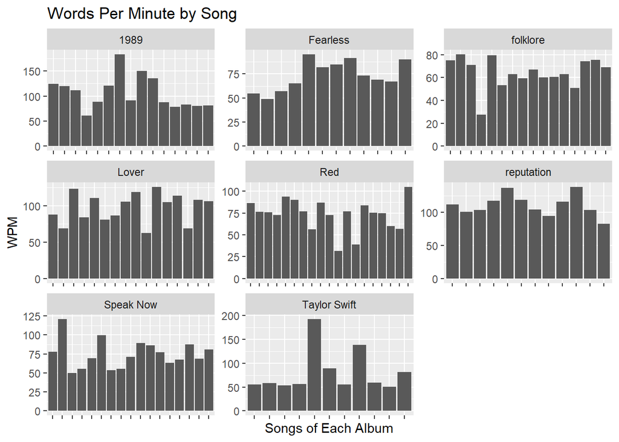

```r
#Plot wpm for each song in each album
wpm_song <- ggplot(temp,aes(x=temp$Title,y=temp$wpm))+
  geom_bar(stat="identity")+
  facet_wrap(vars(Album), scales ="free")+
  theme(axis.text.x = element_blank())+
  ggtitle("Words Per Minute by Song")+
  labs(y = "WPM", x = "Songs of Each Album")
wpm_song
```

**8. Plot wpm for each album**

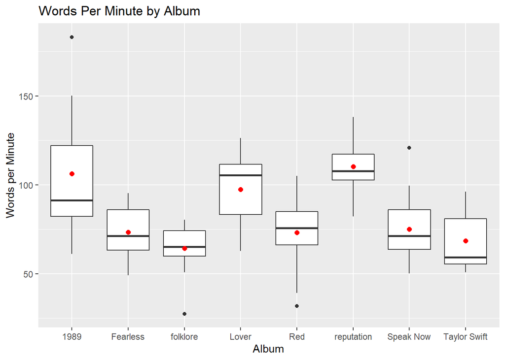

```r
#Plot wpm for each album
wpm_album <- ggplot(temp,aes(x=temp$Album,y=temp$wpm))+
  geom_boxplot()+
  ggtitle("Words Per Minute by Album") +
  ylab("Words per Minute")+xlab("Album")+
  geom_point(stat = "summary", fun="mean", color="red", size =2)
wpm_album
```

```r
#Save the plots. Plots saved for these two are extremely small and barely visible so I manually adjusted the width and height
ggsave("Words Per Minute by Song", plot = wpm_song, device = png, width = 1000, height = 800, limitsize = F)
ggsave("Words Per Minute by Album", plot = wpm_album, device = png, width = 1000, height = 800, limitsize = F)
```

**9. Wpm by albums data.**

```r
#Get started with mean, variance, sd, median, and range for wpm in each album
stat_wpm<-temp%>%
  group_by(Album)%>%
  summarise(mean_wpm = mean(wpm),
            var_wpm = var(wpm),
            sd_wpm = sd(wpm),
            median_wpm = median(wpm),
            range_wpm = max(wpm)-min(wpm))%>%
  arrange(mean_wpm)
print(stat_wpm)
```

```
## # A tibble: 8 x 6
##   Album        mean_wpm var_wpm sd_wpm median_wpm range_wpm
##   <chr>           <dbl>   <dbl>  <dbl>      <dbl>     <dbl>
## 1 folklore         64.3    174.   13.2       65.1      52.8
## 2 Taylor Swift     68.4    278.   16.7       59.1      45.5
## 3 Red              73.2    325.   18.0       75.7      73.4
## 4 Fearless         73.2    237.   15.4       71.2      46.1
## 5 Speak Now        74.9    335.   18.3       71.2      70.8
## 6 Lover            97.5    416.   20.4      105.       63.5
## 7 1989            106.    1070.   32.7       91.3     122.
## 8 reputation      110.     261.   16.1      108.       56.0
```

**By data, “reputation” has the largest wpm and “folklove” has the smallest.**

**10. Analyze how wpm changes between different writers**

```r
#Study how does wpm differs from Taylor being the only writer and Taylor writing with others
temp$Writer.s.<-gsub("Taylor Swift", "Swift", temp$Writer.s.)
temp1<-filter(temp, temp$Writer.s.=="Swift")
temp2<-filter(temp, temp$Writer.s.!="Swift")
(by_Swift_only<-summary(temp1$wpm))
```

```
##    Min. 1st Qu.  Median    Mean 3rd Qu.    Max.
##   31.69   60.71   73.47   72.38   83.71  120.83
```

```r
(by_Swift_others<-summary(temp2$wpm))
```

```
##    Min. 1st Qu.  Median    Mean 3rd Qu.    Max.
##   27.40   68.83   86.38   88.27  106.05  183.19
```

**Lyrics co-composed by Swift and others are more intense in terms of wpm than lyrics written by only Swift.**

**11.Study how does wpm changes corresponding to song length**

```r
#Fit the data into a linear regression model and make an ANOVA
lm_1<-lm(temp$wpm~temp$Length)
print(lm_1)
```

```
##
## Call:
## lm(formula = temp$wpm ~ temp$Length)
##
## Coefficients:
## (Intercept)  temp$Length
##      153.16       -17.84
```

```r
anova(lm_1)
```

```
## Analysis of Variance Table
##
## Response: temp$wpm
##              Df Sum Sq Mean Sq F value    Pr(>F)
## temp$Length   1  16199 16199.0  31.529 1.326e-07 ***
## Residuals   118  60626   513.8
## ---
## Signif. codes:  0 '***' 0.001 '**' 0.01 '*' 0.05 '.' 0.1 ' ' 1
```

```r
summary(lm_1)
```

```
##
## Call:
## lm(formula = temp$wpm ~ temp$Length)
##
## Residuals:
##     Min      1Q  Median      3Q     Max
## -40.559 -16.434   0.015  11.964  91.563
##
## Coefficients:
##             Estimate Std. Error t value Pr(>|t|)
## (Intercept)  153.162     12.693  12.066  < 2e-16 ***
## temp$Length  -17.837      3.177  -5.615 1.33e-07 ***
## ---
## Signif. codes:  0 '***' 0.001 '**' 0.01 '*' 0.05 '.' 0.1 ' ' 1
##
## Residual standard error: 22.67 on 118 degrees of freedom
## Multiple R-squared:  0.2109, Adjusted R-squared:  0.2042
## F-statistic: 31.53 on 1 and 118 DF,  p-value: 1.326e-07
```

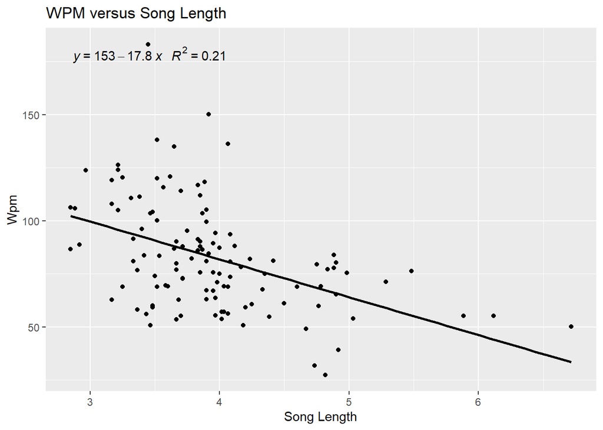

```r
#make a plot of the regression
WPM_Length <- ggplot(temp,aes(y = wpm, x = Length))+
  geom_point()+
  geom_smooth(method = lm, se = F, color = "black")+
  ggtitle("WPM versus Song Length")+
  labs(x = "Song Length", y = "Wpm")+
  stat_poly_eq(formula = temp$wpm~temp$Length,
               aes(label = paste(..eq.label.., ..rr.label.., sep = "~~~")),
               parse = T)
WPM_Length
```

```r
#Save the plot. Again the plot saved is very small so I adjusted width and height
ggsave(filename = "WPM versus Song Length", plot = WPM_Length, device = png, limitsize = F, width = 1000, height = 800)
```

**12. Save mean of wpm as a text file**

```r
#Subset variables album and mean and save as a text file
stat_wpm%>%
  select(Album, mean_wpm)%>%
  write.table(file = "Mean_wpm_albums", sep = "   ", quote = F, )
```

## Conclustion

**We studied total words for each album, finding out that “reputation” has the most words, “Taylor Swift” is with the least words. Taylor Swift loves using first-person pronouns, and “male” pronouns like “he” and “him” are her second favorite probably because of her songs are mostly talking about love. “female” pronouns and “non-binary” comes in third and fourth. In terms of wpm, “reputation is still the one with the most words, and”folklove" takes the least one’s position. Taylor tends to write less words when she composes along, and with others wpm would become larger.**